# Fuel Efficiency Case

SHREYA NADKARNI

14TH OCTOBER 2021

## Load Packages

install.packages(“ROSE”) install.packages(“dplyr”) install.packages(“ggplot2”)

```r
#In this section, we import the necessary data for this lab.
setwd("/Users/SHREYA/Documents/DePaul university/Course Material/MGT 585 Fundamentals of BA")

# import data file
# read the files using read.csv
fueldata <- read.csv(file = "fueldata.csv")
```

# Fuel Efficiency Case

**The U.S. Department of Energy’s Fuel Economy Guide provides fuel efficiency data for cars and trucks. A sample of the data for 311 compact, midsized, and large cars is provided in *fueldata.csv*.**

**The *Class* column identifies the size of the car; Compact, Midsize, or Large.** **The *Displacement* column shows the engine’s displacement in liters.** **The *FuelType* column shows whether the car uses premium (P) or regular (R) fuel, and the *HwyMPG* column shows the fuel efficiency rating for highway driving in terms of miles per gallon.**

**As a Business Analyst, you are asked to use this data to predict the fuel efficiency for highway driving given the engine’s displacement for each class of cars.**

**Do the following tasks and answer the questions according to the tasks’ output.**

## Task 1: Explore your data

```r
# Explore the dataset using 5 functions: dim(), str(), colnames(), head() and tail()

dim(fueldata)
```

```
## [1] 311   5
```

```r
str(fueldata)
```

```
## 'data.frame':    311 obs. of  5 variables:
##  $ Car         : int  1 2 3 4 5 6 7 8 9 10 ...
##  $ Class       : chr  "Compact" "Compact" "Compact" "Compact" ...
##  $ Displacement: num  3.1 3.1 3 3 3 3 2.4 3.5 3 2.4 ...
##  $ FuelType    : chr  "P" "P" "P" "P" ...
##  $ HwyMPG      : int  25 25 25 25 25 25 25 25 25 24 ...
```

```r
colnames(fueldata)
```

```
## [1] "Car"          "Class"        "Displacement" "FuelType"     "HwyMPG"
```

```r
head(fueldata)
```

```
##   Car   Class Displacement FuelType HwyMPG
## 1   1 Compact          3.1        P     25
## 2   2 Compact          3.1        P     25
## 3   3 Compact          3.0        P     25
## 4   4 Compact          3.0        P     25
## 5   5 Compact          3.0        P     25
## 6   6 Compact          3.0        P     25
```

```r
tail(fueldata)
```

```
##     Car Class Displacement FuelType HwyMPG
## 306 306 Large          3.6        R     25
## 307 307 Large          2.4        R     25
## 308 308 Large          3.0        R     25
## 309 309 Large          3.0        R     25
## 310 310 Large          3.0        R     25
## 311 311 Large          3.0        R     25
```

```r
# Convert any column that is supposed to be treated as a factor

table(fueldata$Class)
```

```
##
## Compact   Large Midsize
##     111      65     135
```

```r
fueldata$Class<- as.factor(fueldata$Class)

table(fueldata$FuelType)
```

```
##
##   P   R
## 157 154
```

```r
fueldata$FuelType<- as.factor(fueldata$FuelType)
```

#### **Question 1**: How many observations and variables are in fueldata dataset? Which variables are numerical and which ones are categorical?”

**RESPONSE**

**We have a file data called as Fueldata. I found the number of observation using the dim() function. The number of observations are 311 of 5 variables with column names such as Car, Class, Displacement, FuelType and HwyMPG.**

**The data which is in numerical form is within the columns called Displacement, Car, HwyMPG. Where as on the other hand, the column FuelType and class are variables containing factors or is in categorical format.**

## Task 2: Run descriptive statistics

**Compute descriptive stats for Displacement and HwyMPG for each Class as well as the correlation between Displacement and HwyMPG for each Class.**

```r
# Descriptive stats for Displacement and HwyMPG for each Class

# Displacement


fueldata %>% group_by(Class) %>% summarise(mean=mean(Displacement), sd=sd(Displacement), min=min(Displacement), max=max(Displacement))
```

```
## # A tibble: 3 × 5
##   Class    mean    sd   min   max
##   <fct>   <dbl> <dbl> <dbl> <dbl>
## 1 Compact  4.38 1.10    2.4   6.2
## 2 Large    3.19 0.582   2     5.3
## 3 Midsize  2.50 0.568   1.6   3.9
```

```r
# HwyMPG

fueldata %>% group_by(Class) %>% summarise(mean=mean(HwyMPG), sd=sd(HwyMPG), min=min(HwyMPG), max=max(HwyMPG))
```

```
## # A tibble: 3 × 5
##   Class    mean    sd   min   max
##   <fct>   <dbl> <dbl> <int> <int>
## 1 Compact  21.7 2.72     15    25
## 2 Large    25.5 0.502    25    26
## 3 Midsize  29.4 2.17     26    37
```

```r
# compute correlation between Displacement and HwyMPG for each Class

fueldata %>% group_by(Class) %>%
  summarise(correlation= cor(Displacement,HwyMPG))
```

```
## # A tibble: 3 × 2
##   Class   correlation
##   <fct>         <dbl>
## 1 Compact      -0.719
## 2 Large        -0.226
## 3 Midsize      -0.541
```

#### **Question 2**: Which Class has the *highest* mean Highway MPG? Which Class has the *lowest* variability in Highway MPG? Explain.

**RESPONSE**

**I used the description functions to find the mean sd min and max values for the Highway MPG variable. Looking at the data, I can rightly state that the mean for Midsize cars (Class) is the highest :- 29.4. While on the other hand, compact car class indicate having the lowest mean of 21.7.**

#### **Question 3**: What is the *correlation* between Displacement and HwyMPG for each Class? Does that imply a positive, negative or no relationship? Is the relationship strong? Explain.

**RESPONSE**

## Task 3: Visualization

**Take HwyMPG as a response (dependent variable) and Displacement as a predictor (independent variable).**

**We want to know the impact of HwyMPG. Therefore, HwyMPG is our dependent variable and Displacement is our independent variable. Let’s denote our dependent variable HwyMPG as Y and our independent variable Displacement as X. We first visualize the relationship between X and Y using scatter plots and then run a simple linear regression model for each class.**

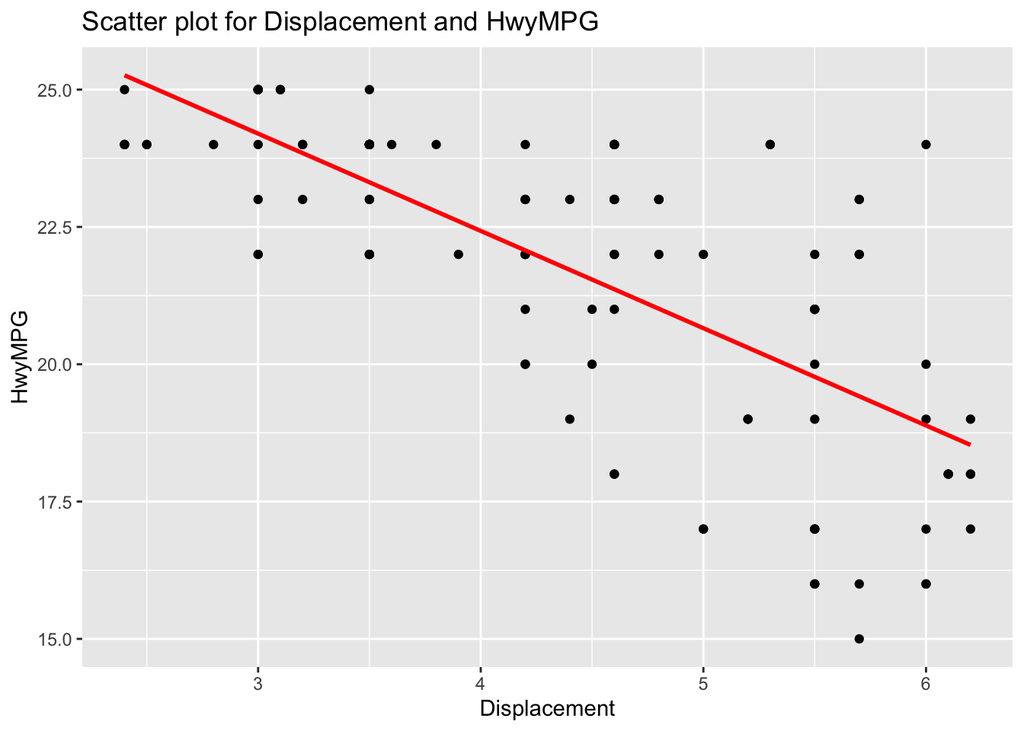

```r
### scatter plot of Displacement and HwyMPG for each Class

## Compact

# Create a new data frame that only includes the data of Class Compact

fueldata_Class <- fueldata %>% filter(Class == 'Compact')

# scatter plot of Displacement and HwyMPG

ggplot(fueldata_Class, mapping = aes(x = Displacement, y = HwyMPG)) +
  geom_point() +
  geom_smooth(method = "lm",se = FALSE, colour = "red") +
  ggtitle("Scatter plot for Displacement and HwyMPG") +
  xlab("Displacement") +
  ylab("HwyMPG")
```

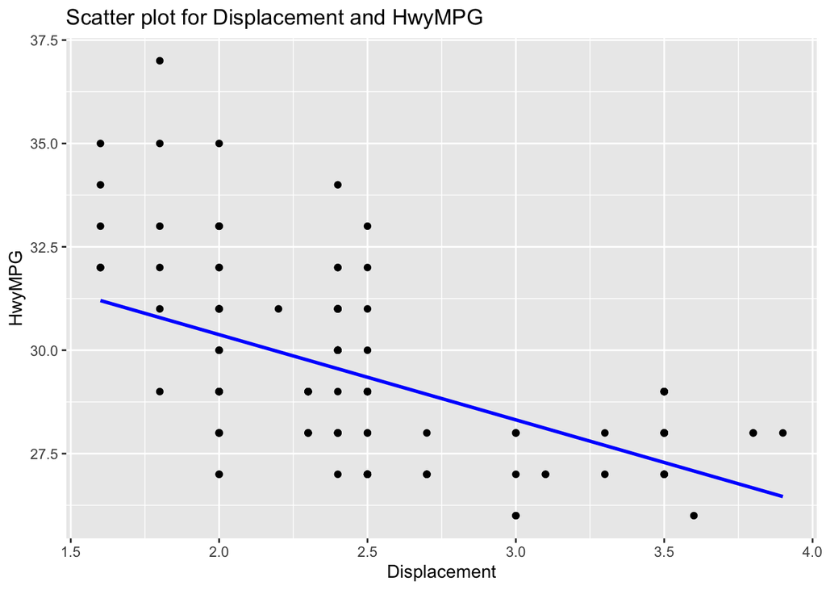

```r
## Midsize

# Create a new data frame that only includes the data of Class Midsize

fueldata_Midsize <- fueldata %>% filter(Class == 'Midsize')

# scatter plot of Displacement and HwyMPG

ggplot(fueldata_Midsize, mapping = aes(x = Displacement, y = HwyMPG)) +
  geom_point() +
  geom_smooth(method = "lm",se = FALSE, colour = "Blue") +
  ggtitle("Scatter plot for Displacement and HwyMPG") +
  xlab("Displacement") +
  ylab("HwyMPG")
```

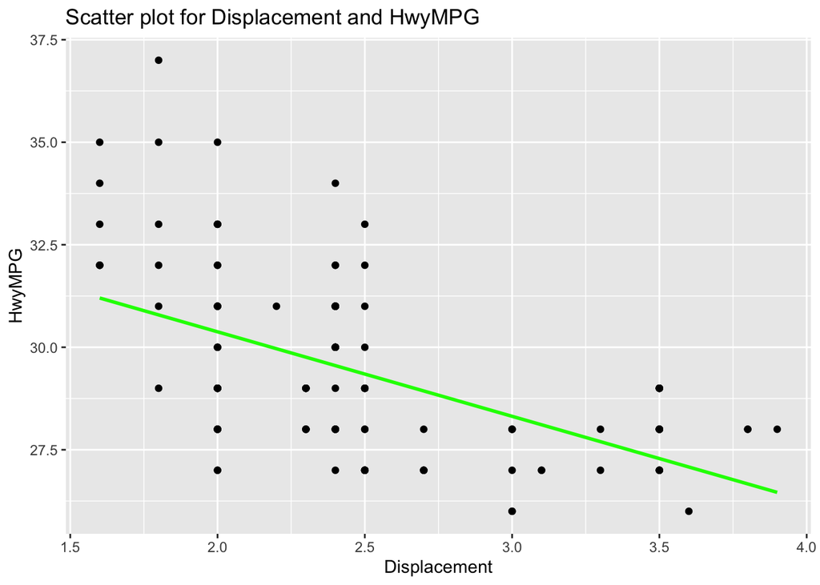

```r
## Large

# Create a new data frame that only includes the data of Class Large

fueldata_Large <- fueldata %>% filter(Class == 'Large')

# scatter plot of Displacement and HwyMPG

ggplot(fueldata_Midsize, mapping = aes(x = Displacement, y = HwyMPG)) +
  geom_point() +
  geom_smooth(method = "lm",se = FALSE, colour = "Green") +
  ggtitle("Scatter plot for Displacement and HwyMPG") +
  xlab("Displacement") +
  ylab("HwyMPG")
```

#### **Question 4** What do the scatter plots show? Write one line for each Class.

**1- Scatter plot for compact class cars indicates a downward slope stating that there is a negative relationship between the two variables.**

**2-Scatter plot for Midsize class cars indicates a downward slope stating that there is a negative relationship between the two variables.**

## Task 4: Simple Linear Regression

**Taking HwyMPG as a response (dependent variable) and Displacement as a predictor (independent variable) and runing regression analyses as instructed below for each Class.**

```r
# The impact of Displacement on HwyMPG

# X is Displacement
# Y is HwyMPG

## Regression Analysis for Class Compact

reg_compact <- lm(HwyMPG ~ Displacement, data= fueldata_Class)
summary(reg_compact)
```

```
##
## Call:
## lm(formula = HwyMPG ~ Displacement, data = fueldata_Class)
##
## Residuals:
##     Min      1Q  Median      3Q     Max
## -4.4166 -1.2613  0.2292  1.0521  5.1148
##
## Coefficients:
##              Estimate Std. Error t value Pr(>|t|)
## (Intercept)   29.5120     0.7406   39.85   <2e-16 ***
## Displacement  -1.7711     0.1639  -10.81   <2e-16 ***
## ---
## Signif. codes:  0 '***' 0.001 '**' 0.01 '*' 0.05 '.' 0.1 ' ' 1
##
## Residual standard error: 1.895 on 109 degrees of freedom
## Multiple R-squared:  0.5173, Adjusted R-squared:  0.5129
## F-statistic: 116.8 on 1 and 109 DF,  p-value: < 2.2e-16
```

```r
## Regression Analysis for Class Midsize

reg_Midsize <- lm(HwyMPG ~ Displacement, data= fueldata_Midsize)
summary(reg_Midsize)
```

```
##
## Call:
## lm(formula = HwyMPG ~ Displacement, data = fueldata_Midsize)
##
## Residuals:
##     Min      1Q  Median      3Q     Max
## -3.3768 -1.4646 -0.2856  1.4475  6.2110
##
## Coefficients:
##              Estimate Std. Error t value Pr(>|t|)
## (Intercept)   34.4984     0.7116  48.478  < 2e-16 ***
## Displacement  -2.0608     0.2781  -7.411 1.31e-11 ***
## ---
## Signif. codes:  0 '***' 0.001 '**' 0.01 '*' 0.05 '.' 0.1 ' ' 1
##
## Residual standard error: 1.829 on 133 degrees of freedom
## Multiple R-squared:  0.2922, Adjusted R-squared:  0.2869
## F-statistic: 54.92 on 1 and 133 DF,  p-value: 1.307e-11
```

```r
## Regression Analysis for Class Large

reg_Large <- lm(HwyMPG ~ Displacement, data= fueldata_Large)
summary(reg_Large)
```

```
##
## Call:
## lm(formula = HwyMPG ~ Displacement, data = fueldata_Large)
##
## Residuals:
##     Min      1Q  Median      3Q     Max
## -0.6925 -0.4778  0.2880  0.4636  0.5807
##
## Coefficients:
##              Estimate Std. Error t value Pr(>|t|)
## (Intercept)   26.1608     0.3437   76.12   <2e-16 ***
## Displacement  -0.1951     0.1060   -1.84   0.0704 .
## ---
## Signif. codes:  0 '***' 0.001 '**' 0.01 '*' 0.05 '.' 0.1 ' ' 1
##
## Residual standard error: 0.4933 on 63 degrees of freedom
## Multiple R-squared:  0.05101,    Adjusted R-squared:  0.03595
## F-statistic: 3.387 on 1 and 63 DF,  p-value: 0.07044
```

#### **Question 5**: Interpreting the results for each Class? Interpret (1) the coefficient estimates, (2) p-value for beta1, (3) R-squared , and (4) p-value for F-statistics.

**1-Compact cars**

**First, the estimate for the intercept and slope are beta0 = 29.5120, beta1 = -1.7711. This indicates a negative relationship between the two variables.**

**Second, p-value for beta1 is < 0.05, therefore Displacement has a significant impact on HwyMPG.**

**Third, R-squared is 0.5173 and it means that we can explain51.73% of variance in our data with this model.**

**Finally, p-value for F-statistics is < 0.05. therefore at least one of the coefficients are non-zero, and the model is valid.**

[output not shown]

**3- Large cars**

**First, the estimate for the intercept and slope are beta0 = 26.1608 beta1 = -0.1951. This indicates a negative relationship between the two variables.**

```r
## Predict a future response for a new data
# choosing the new value for Displacement

## Compact
# predict HwyMPG using the predict function
Displacement = 3
fueldata_Class1 <- data.frame(HwyMPG = 3)
predict(reg_compact, newdata = fueldata_Class1)
```

```
##       1
## 24.1986
```

```r
## Midsize
# predict HwyMPG using the predict function
fueldata_Class1 <- data.frame(HwyMPG = 3)
predict(reg_Midsize, newdata = fueldata_Class1)
```

```
##        1
## 28.31599
```

```r
## Large
# predict HwyMPG using the predict function
fueldata_Class1 <- data.frame(HwyMPG = 3)
predict(reg_Large, newdata = fueldata_Class1)
```

```
##        1
## 25.57539
```